# 04.09

## Отыргашева Мила и Плотникова Вероника

Загрузка библиотек

```python
import pandas as pd
import numpy as np
import matplotlib.pyplot as plt
```

Загрузка датафрейма

```python
df = pd.read_csv('spotify_artist_streaming_2020_2025.csv')
```

```python
df
```

|  | track_id | track_name | artist_name | album_name | release_date | genre | duration_ms | popularity | danceability | energy | ... | popularity_category | loudness_category | key_name | mode_name | is_explicit_bool | release_quarter | is_weekend_release | log_stream_count | upbeat_score | artist_track_count |
| --- | --- | --- | --- | --- | --- | --- | --- | --- | --- | --- | --- | --- | --- | --- | --- | --- | --- | --- | --- | --- | --- |
| 0 | 346d85e2-ffde-41b3-854a-589ed880b91f | Storm | Ethereal | The Hollow Journeys | 2021-10-06 | Pop | 169594 | 47 | 0.6777 | 0.7949 | ... | Medium | Loud | A | Major | False | Q4 | False | 10.7492 | 0.6632 | 3232 |
| 1 | 12bc268a-363b-4f19-8fa8-0ced7ae1e462 | Silent | The Wolfs | Ancient Thunder | 2024-10-26 | K-Pop | 256755 | 26 | 0.9405 | 0.7163 | ... | Medium | Moderate | C# | Major | False | Q4 | True | 8.5895 | 0.7615 | 20 |
| 2 | 30d627d9-878d-4bb3-be59-71feb6ed4f3f | Shattered Lines | LolaOre | Twisted Harbors | 2022-11-12 | Punk | 170212 | 46 | 0.6853 | 0.9500 | ... | Medium | Loud | E | Major | False | Q4 | True | 12.2935 | 0.7828 | 199 |
| 3 | 85501bb9-d221-4339-9e2e-29b1b3daff0a | Breaking Roses | Clay Black | The Blinding Letters | 2020-06-22 | Pop | 181250 | 4 | 0.7817 | 0.6943 | ... | Low | Moderate | F# | Major | False | Q2 | False | 8.5658 | 0.6778 | 693 |
| 4 | 7bf92bd2-c6fe-4869-a90e-242bb8bbe7a3 | Lines | Knot Hart | The Cosmic Letters | 2024-01-22 | Latin | 160894 | 27 | 0.7200 | 0.4958 | ... | Medium | Moderate | C# | Major | False | Q1 | False | 10.2191 | 0.5494 | 12111 |
| ... | ... | ... | ... | ... | ... | ... | ... | ... | ... | ... | ... | ... | ... | ... | ... | ... | ... | ... | ... | ... | ... |
| 49995 | 38913908-e3ab-42a2-9a97-2d1847c21e3b | Flames | Luna Ink | The Shattered Tapes | 2025-02-27 | Hip-Hop | 249380 | 6 | 0.7338 | 0.8172 | ... | Low | Loud | C# | Major | False | Q1 | False | 6.2005 | 0.7545 | 577 |
| 49996 | 83653402-ca85-4583-b7ec-13ab3e82888e | Love | Knot Hart | Young II | 2021-07-25 | Folk | 176329 | 22 | 0.5547 | 0.0000 | ... | Low | Quiet | A# | Minor | True | Q3 | True | 9.1916 | 0.3292 | 12111 |
| 49997 | 4398dd33-ecfc-4c1a-ab9e-248f38082318 | The Waves | Jasper Jade | The Burning Journeys | 2023-12-24 | Pop | 202472 | 5 | 0.6558 | 0.8805 | ... | Low | Moderate | G | Major | True | Q4 | True | 7.8200 | 0.6794 | 181 |
| 49998 | 07c673e7-39a5-4c28-8789-163ae5f17f3f | Flying Eyes | ElaraRain | Frequencies | 2020-08-17 | Rock | 172542 | 81 | 0.5979 | 0.6252 | ... | Very High | Moderate | F# | Minor | False | Q3 | False | 15.1911 | 0.5622 | 1111 |
| 49999 | 888e233c-e7fd-4c0d-af8a-3cd98345a64e | Roads | Edge Brooks | Wicked III | 2020-11-19 | Hip-Hop | 198469 | 27 | 0.9388 | 0.6830 | ... | Medium | Moderate | G# | Minor | True | Q4 | False | 9.3957 | 0.7795 | 65 |

50000 rows × 33 columns

Вывод первых 10 строк

```python
df.head(10)
```

|  | track_id | track_name | artist_name | album_name | release_date | genre | duration_ms | popularity | danceability | energy | ... | popularity_category | loudness_category | key_name | mode_name | is_explicit_bool | release_quarter | is_weekend_release | log_stream_count | upbeat_score | artist_track_count |
| --- | --- | --- | --- | --- | --- | --- | --- | --- | --- | --- | --- | --- | --- | --- | --- | --- | --- | --- | --- | --- | --- |
| 0 | 346d85e2-ffde-41b3-854a-589ed880b91f | Storm | Ethereal | The Hollow Journeys | 2021-10-06 | Pop | 169594 | 47 | 0.6777 | 0.7949 | ... | Medium | Loud | A | Major | False | Q4 | False | 10.7492 | 0.6632 | 3232 |
| 1 | 12bc268a-363b-4f19-8fa8-0ced7ae1e462 | Silent | The Wolfs | Ancient Thunder | 2024-10-26 | K-Pop | 256755 | 26 | 0.9405 | 0.7163 | ... | Medium | Moderate | C# | Major | False | Q4 | True | 8.5895 | 0.7615 | 20 |
| 2 | 30d627d9-878d-4bb3-be59-71feb6ed4f3f | Shattered Lines | LolaOre | Twisted Harbors | 2022-11-12 | Punk | 170212 | 46 | 0.6853 | 0.9500 | ... | Medium | Loud | E | Major | False | Q4 | True | 12.2935 | 0.7828 | 199 |
| 3 | 85501bb9-d221-4339-9e2e-29b1b3daff0a | Breaking Roses | Clay Black | The Blinding Letters | 2020-06-22 | Pop | 181250 | 4 | 0.7817 | 0.6943 | ... | Low | Moderate | F# | Major | False | Q2 | False | 8.5658 | 0.6778 | 693 |
| 4 | 7bf92bd2-c6fe-4869-a90e-242bb8bbe7a3 | Lines | Knot Hart | The Cosmic Letters | 2024-01-22 | Latin | 160894 | 27 | 0.7200 | 0.4958 | ... | Medium | Moderate | C# | Major | False | Q1 | False | 10.2191 | 0.5494 | 12111 |
| 5 | e4a536ca-c6d4-4bad-97b5-d5e7b85c49e2 | Wild Doors | Knot Hart | Jagged Gardens | 2021-04-12 | R&B | 198179 | 28 | 0.6538 | 0.3732 | ... | Medium | Moderate | G# | Major | False | Q2 | False | 9.8292 | 0.4586 | 12111 |
| 6 | 305b4f13-b2ac-47e9-a6f2-d0c15934f8b6 | Skies | Knot Hart | The Ancient Tapes | 2025-07-16 | R&B | 251330 | 18 | 0.7399 | 0.4000 | ... | Low | Moderate | G | Minor | False | Q3 | False | 9.6072 | 0.5475 | 12111 |
| 7 | 83c3a6be-6066-449a-a339-19afcde7cfb3 | Wild | Blaze Project | Crystal | 2023-12-12 | Classical | 208198 | 15 | 0.1730 | 0.3085 | ... | Low | Moderate | G# | Major | True | Q4 | False | 6.9745 | 0.2482 | 53 |
| 8 | 437961fc-9ccd-4c86-8eb7-e96b6d2dc5c8 | Neon Oceans | Clay Black | Broken V | 2020-06-17 | Pop | 254751 | 23 | 0.6838 | 0.5026 | ... | Low | Moderate | G | Minor | True | Q2 | False | 8.3301 | 0.5249 | 693 |
| 9 | 53df0c89-adc4-48b7-94e3-111e348cb17b | Eternal Angels | Phantasm | The Kind Notes | 2020-06-09 | Trap | 310076 | 39 | 0.5759 | 0.8349 | ... | Medium | Moderate | D# | Minor | False | Q2 | False | 12.1223 | 0.6488 | 242 |

10 rows × 33 columns

Определяем количество строк и столбцов

```python
df.shape
```

```
(50000, 33)
```

Вывод названия столбцов в виде Index

```python
df.columns
```

```
Index(['track_id', 'track_name', 'artist_name', 'album_name', 'release_date',
       'genre', 'duration_ms', 'popularity', 'danceability', 'energy', 'key',
       'loudness', 'mode', 'instrumentalness', 'tempo', 'stream_count',
       'country', 'explicit', 'label', 'release_year', 'release_month',
       'release_day_of_week', 'duration_minutes', 'popularity_category',
       'loudness_category', 'key_name', 'mode_name', 'is_explicit_bool',
       'release_quarter', 'is_weekend_release', 'log_stream_count',
       'upbeat_score', 'artist_track_count'],
      dtype='object')
```

Просмотр типов данных столбцов и общей информации о датасете

```python
df.info()
```

```
<class 'pandas.core.frame.DataFrame'>
RangeIndex: 50000 entries, 0 to 49999
Data columns (total 33 columns):
 #   Column               Non-Null Count  Dtype
---  ------               --------------  -----
 0   track_id             50000 non-null  object
 1   track_name           50000 non-null  object
 2   artist_name          50000 non-null  object
 3   album_name           50000 non-null  object
 4   release_date         50000 non-null  object
 5   genre                50000 non-null  object
 6   duration_ms          50000 non-null  int64
 7   popularity           50000 non-null  int64
 8   danceability         50000 non-null  float64
 9   energy               50000 non-null  float64
```

[output cut: 25 more lines]

### Сортировка данных

Сортировка датасета по убыванию столбца stream_count и выборка первых 10 строк

```python
top_tracks = df.sort_values(by='stream_count', ascending=False).head(10)
top_tracks[['track_name', 'artist_name', 'genre', 'stream_count']]
```

|  | track_name | artist_name | genre | stream_count |
| --- | --- | --- | --- | --- |
| 1528 | The Roses | Grove Nova | Alternative | 43345015 |
| 36998 | Bitter | Flora Quinn | Rock | 26635547 |
| 42813 | The Streets | Ethereal | Pop | 26314312 |
| 21643 | Breaking Thunder | SethStone | Metal | 20408155 |
| 49193 | The Pages | IsleEyre | Pop | 19265301 |
| 26622 | Lights | Dean System | Hip-Hop | 17238449 |
| 45015 | Gentle | Rocco Ore | R&B | 15776187 |
| 39012 | Storm | Knot Hart | R&B | 14545933 |
| 29091 | Burning Islands | The Inks | Pop | 14507867 |
| 13635 | Broken Eyes | Prism Hart | R&B | 14367106 |

### Фильтрация

Фильтрация датасета только с теми треками, у которых release_year строго больше 2024. Выводим первые 10 строк для проверки

```python
filtered_tracks = df[df['release_year'] > 2024]
filtered_tracks[['track_name', 'artist_name', 'release_year']].head(10)
```

|  | track_name | artist_name | release_year |
| --- | --- | --- | --- |
| 6 | Skies | Knot Hart | 2025 |
| 14 | The Roads | Knot Hart | 2025 |
| 17 | Liquid Streets | ElaraRain | 2025 |
| 18 | Broken Ghosts | Sterling Zen | 2025 |
| 24 | The Tears | Sterling Zen | 2025 |
| 27 | Eternal | SethStone | 2025 |
| 42 | Waiting Night | Knot Hart | 2025 |
| 46 | Oceans | IsleEyre | 2025 |
| 50 | Empty Flames | Onyx Core | 2025 |
| 60 | Young Floors | Ethereal | 2025 |

### Основные статистические показатели

```python
df['popularity'].describe()
```

```
count    50000.000000
mean        28.136820
std         15.999501
min          0.000000
25%         16.000000
50%         26.000000
75%         39.000000
max         92.000000
Name: popularity, dtype: float64
```

##### count: общее количество значений

##### mean: среднее арифметическое значение

##### std: стандартное отклонение, показывающее средний разброс данных относительно среднего значения

##### min: минимальное значение в выборке

##### max: максимальное значение в выборке

Наиболее часто встречающееся значение мода для столбцов genre и release_year

```python
df['genre'].mode()[0], df['release_year'].mode()[0]
```

```
('R&B', 2024)
```

### Гистограмма распределения значений popularity

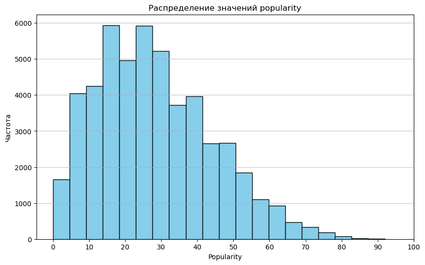

```python
plt.figure(figsize=(10, 6))
plt.hist(df['popularity'], bins=20, color='skyblue', edgecolor='black')
plt.title('Распределение значений popularity')
plt.xlabel('Popularity')
plt.ylabel('Частота')
plt.xticks(range(0, 101, 10))
plt.grid(axis='y', alpha=0.75)
plt.show()
```

#### 1. Основная часть значений находится в диапазоне от 10 до 40

#### 2. Значения выше 60 встречаются значительно реже остальных

## Вывод по практической работе

В ходе практической работы были повторены базовые навыки использования Python и библиотеки Pandas. Были загружены данные из CSV-файла, проведены анализ структуры, сортировка и фильтрация, рассчитаны статистические метрики и построена гистограмма распределения признака популярности.

## Контрольные вопросы

### 1. Что такое DataFrame?

DataFrame — это табличная структура данных с именованными столбцами и индексами строк, предназначенная для удобного хранения, преобразования и анализа структурированных данных в аналитических и научных вычислениях.

### 2. Что такое признак (Feature)?

Признак (feature) — отдельная измеримая характеристика примера, по которой модель делает вывод. В таблице датасета признаки — это столбцы: возраст, сумма покупки, длина текста, время суток. От выбора признаков качество модели зависит сильнее, чем от алгоритма.

### 3. Чем среднее арифметическое отличается от медианы?

Среднее арифметическое (mean) рассчитывается как сумма всех значений выборки, деленная на их количество. Медиана (median) — это значение, которое делит упорядоченный по возрастанию набор данных пополам: 50% значений в выборке меньше медианы, а остальные 50% — больше. На медиану не влияют экстремально высокие или низкие значения.

### 4. Что показывает гистограмма?

Гистограмма — это графическое представление распределения числовых данных. Она демонстрирует, как часто значения признака попадают в определенные интервалы.

### 5. Для чего нужна фильтрация данных?

Фильтрация данных необходима для отбора подмножества строк из исходного набора данных, которые удовлетворяют заданным логическим условиям.